# R Notebook

Data input and construct a DESeqDataSet

```r
library("tximport")
library("readr")
dir <- system.file("extdata", package="tximportData")
counts <- read.table(file.path(dir,"sample003.csv"), header=TRUE)
counts$condition <- factor(rep(c("TNB","HR"),each=20))
rownames(counts) <- samples$run
counts[,c("TNB_sample1","TNB_sample2","TNB_sample3","TNB_sample4")]
```

```r
sample003 <- read_csv("/users/batulal-zubeidy/Desktop/TRGNFinal/TNB_HR_Joined_counts.csv")
```

```r
head(sample003)
```

| gene_id | TNB_Sample1 | TNB_Sample2 | TNB_Sample3 | TNB_Sample4 | TNB_Sample5 | TNB_Sample6 | TNB_Sample7 | TNB_Sample8 | TNB_Sample9 | TNB_Sample10 | HR_Sample1 | HR_Sample2 | HR_Sample3 | HR_Sample4 | HR_Sample5 | HR_Sample6 | HR_Sample7 | HR_Sample8 | HR_Sample9 | HR_Sample10 |
| --- | --- | --- | --- | --- | --- | --- | --- | --- | --- | --- | --- | --- | --- | --- | --- | --- | --- | --- | --- | --- |
| ENSG00000000003.15 | 11.5131 | 16.1181 | 31.7164 | 14.1300 | 26.1442 | 22.1580 | 20.4186 | 18.7707 | 11.0678 | 33.6260 | 10.1119 | 5.9878 | 23.5964 | 3.5103 | 13.5934 | 4.0979 | 12.6241 | 35.9733 | 3.4008 | 13.4414 |
| ENSG00000000005.6 | 0.0133 | 0.0746 | 0.0568 | 0.1357 | 1.7059 | 0.0146 | 0.0177 | 0.0098 | 0.0647 | 0.1156 | 0.1033 | 0.0145 | 0.0436 | 0.0134 | 0.0293 | 0.1173 | 0.8171 | 0.0000 | 0.0757 | 0.8132 |
| ENSG00000000419.13 | 51.8071 | 49.7934 | 17.8525 | 39.6740 | 39.5339 | 32.1221 | 20.9227 | 20.0057 | 44.3501 | 37.0361 | 20.8171 | 43.6567 | 39.3780 | 28.6561 | 24.4397 | 60.9148 | 38.5795 | 42.6416 | 29.0403 | 21.0414 |
| ENSG00000000457.14 | 3.1431 | 2.9941 | 2.0035 | 2.9562 | 2.9588 | 2.9805 | 2.0324 | 6.3745 | 5.9706 | 4.4702 | 8.0737 | 4.1857 | 8.6708 | 1.6970 | 3.8267 | 5.9742 | 3.9350 | 4.5274 | 3.7005 | 3.1490 |
| ENSG00000000460.17 | 2.6883 | 3.6457 | 2.4081 | 1.7676 | 3.5933 | 1.8406 | 0.6442 | 4.9303 | 5.2918 | 6.7108 | 1.6924 | 1.6648 | 3.6589 | 1.1369 | 1.7474 | 3.1136 | 1.0277 | 1.8861 | 1.3321 | 0.8887 |
| ENSG00000000938.13 | 1.6224 | 7.6889 | 0.9116 | 2.7384 | 2.2481 | 3.7959 | 9.4023 | 2.2914 | 1.9715 | 5.2952 | 1.1837 | 6.5869 | 0.5085 | 2.3920 | 1.7150 | 2.1563 | 2.7212 | 0.5161 | 4.2684 | 2.0985 |

```r
counts <- read.csv("/Users/batulal-zubeidy/Desktop/TRGNFinal/TNB_HR_Joined_Counts.csv", header = TRUE, row.names = 1, sep = ",")
```

```r
head(counts)
```

|  | TNB_Sample1 | TNB_Sample2 | TNB_Sample3 | TNB_Sample4 | TNB_Sample5 | TNB_Sample6 | TNB_Sample7 | TNB_Sample8 | TNB_Sample9 | TNB_Sample10 | HR_Sample1 | HR_Sample2 | HR_Sample3 | HR_Sample4 | HR_Sample5 | HR_Sample6 | HR_Sample7 | HR_Sample8 | HR_Sample9 | HR_Sample10 |
| --- | --- | --- | --- | --- | --- | --- | --- | --- | --- | --- | --- | --- | --- | --- | --- | --- | --- | --- | --- | --- |
| ENSG00000000003.15 | 11.5131 | 16.1181 | 31.7164 | 14.1300 | 26.1442 | 22.1580 | 20.4186 | 18.7707 | 11.0678 | 33.6260 | 10.1119 | 5.9878 | 23.5964 | 3.5103 | 13.5934 | 4.0979 | 12.6241 | 35.9733 | 3.4008 | 13.4414 |
| ENSG00000000005.6 | 0.0133 | 0.0746 | 0.0568 | 0.1357 | 1.7059 | 0.0146 | 0.0177 | 0.0098 | 0.0647 | 0.1156 | 0.1033 | 0.0145 | 0.0436 | 0.0134 | 0.0293 | 0.1173 | 0.8171 | 0.0000 | 0.0757 | 0.8132 |
| ENSG00000000419.13 | 51.8071 | 49.7934 | 17.8525 | 39.6740 | 39.5339 | 32.1221 | 20.9227 | 20.0057 | 44.3501 | 37.0361 | 20.8171 | 43.6567 | 39.3780 | 28.6561 | 24.4397 | 60.9148 | 38.5795 | 42.6416 | 29.0403 | 21.0414 |
| ENSG00000000457.14 | 3.1431 | 2.9941 | 2.0035 | 2.9562 | 2.9588 | 2.9805 | 2.0324 | 6.3745 | 5.9706 | 4.4702 | 8.0737 | 4.1857 | 8.6708 | 1.6970 | 3.8267 | 5.9742 | 3.9350 | 4.5274 | 3.7005 | 3.1490 |
| ENSG00000000460.17 | 2.6883 | 3.6457 | 2.4081 | 1.7676 | 3.5933 | 1.8406 | 0.6442 | 4.9303 | 5.2918 | 6.7108 | 1.6924 | 1.6648 | 3.6589 | 1.1369 | 1.7474 | 3.1136 | 1.0277 | 1.8861 | 1.3321 | 0.8887 |
| ENSG00000000938.13 | 1.6224 | 7.6889 | 0.9116 | 2.7384 | 2.2481 | 3.7959 | 9.4023 | 2.2914 | 1.9715 | 5.2952 | 1.1837 | 6.5869 | 0.5085 | 2.3920 | 1.7150 | 2.1563 | 2.7212 | 0.5161 | 4.2684 | 2.0985 |

```r
library("DESeq2")
dds <- DESeqDataSetFromTximport(txi,
                                   colData = samples,
                                   design = ~ condition)
```

```r
samplesFiles <- grep("TNB_sample1",list.files("TNB_HR_Joined"), value = TRUE)
```

```r
counts <- counts[which(rowSums(counts) >1),]
```

```r
condition <- factor(c("TNB_Sample1", "TNB_Sample2", "TNB_Sample3", "TNB_Sample4", "TNB_Sample5", "TNB_Sample6", "TNB_Sample7", "TNB_Sample8", "TNB_Sample9", "TNB_Sample10", "HR_Sample1", "HR_Sample2", "HR_Sample3", "HR_Sample4", "HR_Sample5", "HR_Sample6", "HR_Sample7", "HR_Sample8", "HR_Sample9", "HR_Sample10"))
```

```r
coldata
```

|  | condition |
| --- | --- |
| TNB_Sample1 | TNB_Sample1 |
| TNB_Sample2 | TNB_Sample2 |
| TNB_Sample3 | TNB_Sample3 |
| TNB_Sample4 | TNB_Sample4 |
| TNB_Sample5 | TNB_Sample5 |
| TNB_Sample6 | TNB_Sample6 |
| TNB_Sample7 | TNB_Sample7 |
| TNB_Sample8 | TNB_Sample8 |
| TNB_Sample9 | TNB_Sample9 |
| TNB_Sample10 | TNB_Sample10 |

[output cut: 10 more lines]

```r
rownames(coldata) <- sub("fb", "", rownames(coldata))
all(rownames(coldata) %in% colnames(cts))
```

```
[1] FALSE
```

```r
all(rownames(coldata) == colnames(cts))
```

```
[1] FALSE
```

```r
cts <- cts[, rownames(coldata)]
```

```
Error in cts[, rownames(coldata)] : subscript out of bounds
```

```r
dds <- DESeqDataSetFromMatrix(countData = round(counts), colData = metadata, design = ~condition)
```

```
Warning: some variables in design formula are characters, converting to factors
```

```r
library("DESeq2")
dds <- DESeqDataSetFromMatrix(countData = round(counts), colData = metadata, design = ~condition)
```

```
Warning: some variables in design formula are characters, converting to factors
```

```r
dds <- DESeq(dds)
```

```
-- replacing outliers and refitting for 454 genes
-- DESeq argument 'minReplicatesForReplace' = 7
-- original counts are preserved in counts(dds)
```

```r
featureData <- data.frame(gene=rownames(counts))
mcols(dds) <- DataFrame(mcols(dds), featureData)
mcols(dds)
```

```
DataFrame with 29475 rows and 24 columns
                    baseMean    baseVar   allZero dispGeneEst
                   <numeric>  <numeric> <logical>   <numeric>
ENSG00000000003.15 16.763039  97.570254     FALSE  0.29415156
ENSG00000000005.6   0.200285   0.265631     FALSE  0.00000001
ENSG00000000419.13 34.778701 122.455260     FALSE  0.07630107
ENSG00000000457.14  4.149625   3.278973     FALSE  0.00000001
ENSG00000000460.17  2.655753   2.442957     FALSE  0.00000001
...                      ...        ...       ...         ...
ENSG00000288658.1   0.167784   0.298255     FALSE       1e-08
ENSG00000288663.1   0.000000   0.000000      TRUE          NA
ENSG00000288667.1   0.000000   0.000000      TRUE          NA
ENSG00000288670.1   4.403388   6.719429     FALSE       1e-08
ENSG00000288675.1   0.164325   0.295933     FALSE       1e-08
                   dispGeneIter   dispFit dispersion  dispIter
                      <numeric> <numeric>  <numeric> <numeric>
ENSG00000000003.15            8  0.423119  0.3043108         7
ENSG00000000005.6             2 15.735860 14.9773903         7
ENSG00000000419.13            7  0.327200  0.0904311        10
ENSG00000000457.14           31  0.985969  0.1056399         9
ENSG00000000460.17            7  1.406733  0.1506466         9
...                         ...       ...        ...       ...
ENSG00000288658.1             1 18.737939  20.000000         7
ENSG00000288663.1            NA        NA         NA        NA
ENSG00000288667.1            NA        NA         NA        NA
ENSG00000288670.1            27  0.942861   0.150811         9
ENSG00000288675.1             1 19.127356  20.000000         7
                   dispOutlier    dispMAP Intercept condition_TNB_vs_HR
                     <logical>  <numeric> <numeric>           <numeric>
ENSG00000000003.15       FALSE  0.3043108  3.633355           0.7646162
ENSG00000000005.6        FALSE 14.9773903 -1.902656           0.0704867
ENSG00000000419.13       FALSE  0.0904311  5.078483           0.0872382
ENSG00000000457.14       FALSE  0.1056399  2.250268          -0.4174012
ENSG00000000460.17       FALSE  0.1506466  0.881976           0.9412521
...                        ...        ...       ...                 ...
ENSG00000288658.1        FALSE  20.000000  -2.47973            0.936091
ENSG00000288663.1           NA         NA        NA                  NA
ENSG00000288667.1           NA         NA        NA                  NA
ENSG00000288670.1        FALSE   0.150811   2.48787           -0.787317
ENSG00000288675.1        FALSE  20.000000  -2.47973            0.936091
```

[output cut: 63 more lines]

```
ENSG00000288670.1       TRUE         3   85.8247        NA     FALSE
ENSG00000288675.1       TRUE         2   17.7461        NA     FALSE
                                 gene
                          <character>
ENSG00000000003.15 ENSG00000000003.15
ENSG00000000005.6   ENSG00000000005.6
ENSG00000000419.13 ENSG00000000419.13
ENSG00000000457.14 ENSG00000000457.14
ENSG00000000460.17 ENSG00000000460.17
...                               ...
ENSG00000288658.1   ENSG00000288658.1
ENSG00000288663.1   ENSG00000288663.1
ENSG00000288667.1   ENSG00000288667.1
ENSG00000288670.1   ENSG00000288670.1
ENSG00000288675.1   ENSG00000288675.1
```

Gene differential expression analysis

```r
dds <- DESeq(dds)
```

```r
res <- results(dds)
res
```

```
log2 fold change (MLE): condition TNB vs HR
Wald test p-value: condition TNB vs HR
DataFrame with 29475 rows and 6 columns
                    baseMean log2FoldChange     lfcSE       stat
                   <numeric>      <numeric> <numeric>  <numeric>
ENSG00000000003.15 16.763039      0.7646162  0.391395  1.9535665
ENSG00000000005.6   0.200285      0.0704867  2.658405  0.0265147
ENSG00000000419.13 34.778701      0.0872382  0.222725  0.3916856
ENSG00000000457.14  4.149625     -0.4174012  0.382379 -1.0915911
ENSG00000000460.17  2.655753      0.9412521  0.482453  1.9509732
...                      ...            ...       ...        ...
ENSG00000288658.1   0.167784       0.936091  3.026188    0.30933
ENSG00000288663.1   0.000000             NA        NA         NA
ENSG00000288667.1   0.000000             NA        NA         NA
ENSG00000288670.1   4.403388      -0.787317  0.405377   -1.94218
ENSG00000288675.1   0.164325       0.936091  3.026188    0.30933
                      pvalue      padj
                   <numeric> <numeric>
ENSG00000000003.15 0.0507525  0.224028
ENSG00000000005.6  0.9788468        NA
ENSG00000000419.13 0.6952906  0.875994
ENSG00000000457.14 0.2750129  0.568636
ENSG00000000460.17 0.0510602  0.224731
...                      ...       ...
ENSG00000288658.1   0.757070        NA
ENSG00000288663.1         NA        NA
ENSG00000288667.1         NA        NA
ENSG00000288670.1   0.052115  0.228201
ENSG00000288675.1   0.757070        NA
```

Fitting data into the model for analysis

```r
res <- results(dds, contrast = c("condition", "TNB", "HR"))
```

```r
res
```

```
log2 fold change (MLE): condition TNB vs HR
Wald test p-value: condition TNB vs HR
DataFrame with 29475 rows and 6 columns
                    baseMean log2FoldChange     lfcSE       stat
                   <numeric>      <numeric> <numeric>  <numeric>
ENSG00000000003.15 16.763039      0.7646162  0.391395  1.9535665
ENSG00000000005.6   0.200285      0.0704867  2.658405  0.0265147
ENSG00000000419.13 34.778701      0.0872382  0.222725  0.3916856
ENSG00000000457.14  4.149625     -0.4174012  0.382379 -1.0915911
ENSG00000000460.17  2.655753      0.9412521  0.482453  1.9509732
...                      ...            ...       ...        ...
ENSG00000288658.1   0.167784       0.936091  3.026188    0.30933
ENSG00000288663.1   0.000000             NA        NA         NA
ENSG00000288667.1   0.000000             NA        NA         NA
ENSG00000288670.1   4.403388      -0.787317  0.405377   -1.94218
ENSG00000288675.1   0.164325       0.936091  3.026188    0.30933
                      pvalue      padj
                   <numeric> <numeric>
ENSG00000000003.15 0.0507525  0.224028
ENSG00000000005.6  0.9788468        NA
ENSG00000000419.13 0.6952906  0.875994
ENSG00000000457.14 0.2750129  0.568636
ENSG00000000460.17 0.0510602  0.224731
...                      ...       ...
ENSG00000288658.1   0.757070        NA
ENSG00000288663.1         NA        NA
ENSG00000288667.1         NA        NA
ENSG00000288670.1   0.052115  0.228201
ENSG00000288675.1   0.757070        NA
```

```r
library("BiocParallel")
register(MulticoreParam(4))
```

p-values and adjusted p-values

```r
resOrdered <- res[order(res$pvalue),]
```

```r
summary(res)
```

```
out of 24998 with nonzero total read count
adjusted p-value < 0.1
LFC > 0 (up)       : 1135, 4.5%
LFC < 0 (down)     : 824, 3.3%
outliers [1]       : 0, 0%
low counts [2]     : 10121, 40%
(mean count < 1)
[1] see 'cooksCutoff' argument of ?results
[2] see 'independentFiltering' argument of ?results
```

```r
sum(res$padj < 0.1, na.rm=TRUE)
```

```
[1] 1959
```

```r
res05 <- results(dds, alpha=0.05)
summary(res05)
```

```
out of 24998 with nonzero total read count
adjusted p-value < 0.05
LFC > 0 (up)       : 805, 3.2%
LFC < 0 (down)     : 544, 2.2%
outliers [1]       : 0, 0%
low counts [2]     : 11561, 46%
(mean count < 1)
[1] see 'cooksCutoff' argument of ?results
[2] see 'independentFiltering' argument of ?results
```

```r
sum(res05$padj < 0.05, na.rm=TRUE)
```

```
[1] 1349
```

Independent hypothesis weighting:

```r
# (unevaluated code chunk)
library("IHW")
resIHW <- results(dds, filterFun=ihw)
summary(resIHW)
```

```
out of 24998 with nonzero total read count
adjusted p-value < 0.1
LFC > 0 (up)       : 1168, 4.7%
LFC < 0 (down)     : 800, 3.2%
outliers [1]       : 0, 0%
[1] see 'cooksCutoff' argument of ?results
see metadata(res)$ihwResult on hypothesis weighting
```

```r
sum(resIHW$padj < 0.1, na.rm=TRUE)
```

```
[1] 1968
```

```r
metadata(resIHW)$ihwResult
```

```
ihwResult object with 29475 hypothesis tests
Nominal FDR control level: 0.1
Split into 16 bins, based on an ordinal covariate
```

Exploring and exporting results: MA-plot

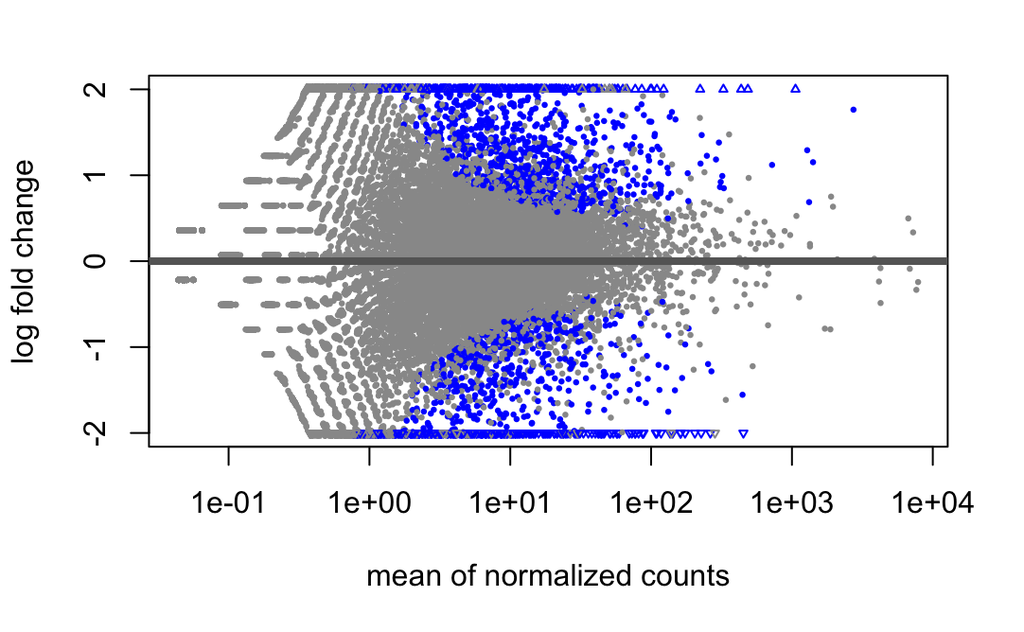

```r
plotMA(res, ylim=c(-2,2))
```

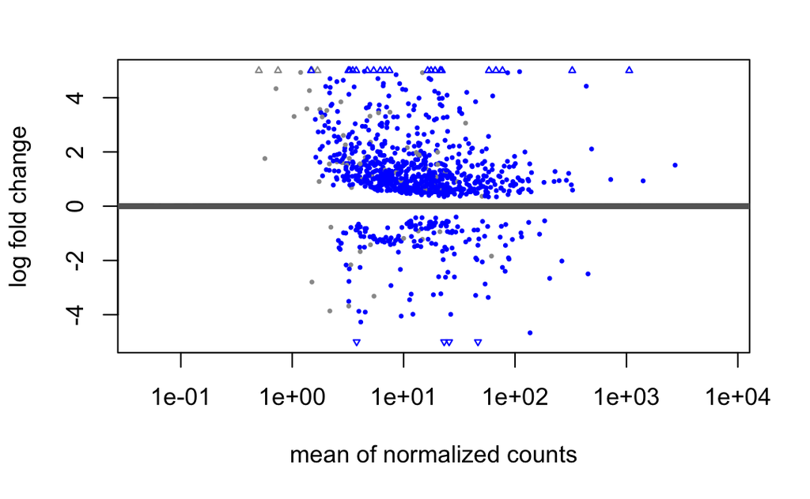

```r
plotMA(resLFC, ylim=c(-5,5))
```

Alternative shrinkage estimators:

```r
BiocManager::install("apeglm")
```

```r
install.packages("CRAN")
```

```r
resultsNames(dds)
```

```
[1] "Intercept"           "condition_TNB_vs_HR"
```

```r
resLFC <-lfcShrink(dds, coef=2, type="apeglm")
```

```
using 'apeglm' for LFC shrinkage. If used in published research, please cite:
    Zhu, A., Ibrahim, J.G., Love, M.I. (2018) Heavy-tailed prior distributions for
    sequence count data: removing the noise and preserving large differences.
    Bioinformatics. https://doi.org/10.1093/bioinformatics/bty895
```

```r
resLFC
```

```
log2 fold change (MAP): condition TNB vs HR
Wald test p-value: condition TNB vs HR
DataFrame with 29475 rows and 5 columns
                    baseMean log2FoldChange      lfcSE    pvalue
                   <numeric>      <numeric>  <numeric> <numeric>
ENSG00000000003.15 16.763039    5.12115e-06 0.00144269 0.0507525
ENSG00000000005.6   0.200285   -1.01830e-08 0.00144269 0.9788468
ENSG00000000419.13 34.778701    1.84332e-06 0.00144267 0.6952906
ENSG00000000457.14  4.149625   -2.99755e-06 0.00144269 0.2750129
ENSG00000000460.17  2.655753    4.36480e-06 0.00144269 0.0510602
...                      ...            ...        ...       ...
ENSG00000288658.1   0.167784    2.72620e-07 0.00144269  0.757070
ENSG00000288663.1   0.000000             NA         NA        NA
ENSG00000288667.1   0.000000             NA         NA        NA
ENSG00000288670.1   4.403388   -9.07024e-06 0.00144270  0.052115
ENSG00000288675.1   0.164325    2.71540e-07 0.00144269  0.757070
                        padj
                   <numeric>
ENSG00000000003.15  0.224028
ENSG00000000005.6         NA
ENSG00000000419.13  0.875994
ENSG00000000457.14  0.568636
ENSG00000000460.17  0.224731
...                      ...
ENSG00000288658.1         NA
ENSG00000288663.1         NA
ENSG00000288667.1         NA
ENSG00000288670.1   0.228201
ENSG00000288675.1         NA
```

```r
install.packages("ashr")
```

```r
resAsh <- lfcShrink(dds, coef=2, type="ashr")
```

```
using 'ashr' for LFC shrinkage. If used in published research, please cite:
    Stephens, M. (2016) False discovery rates: a new deal. Biostatistics, 18:2.
    https://doi.org/10.1093/biostatistics/kxw041
```

```r
# because we are interested in treated vs untreated, we set 'coef=2'
resNorm <- lfcShrink(dds, coef=2, type="normal")
```

```r
par(mfrow=c(1,3), mar=c(4,4,2,1))
xlim <- c(1,1e5); ylim <- c(-3,3)
```

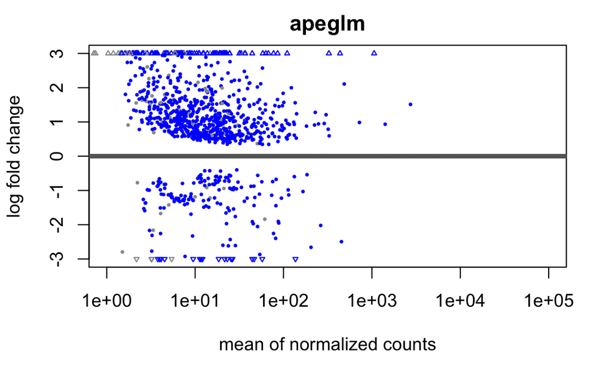

```r
plotMA(resLFC, xlim=xlim, ylim=ylim, main="apeglm")
```

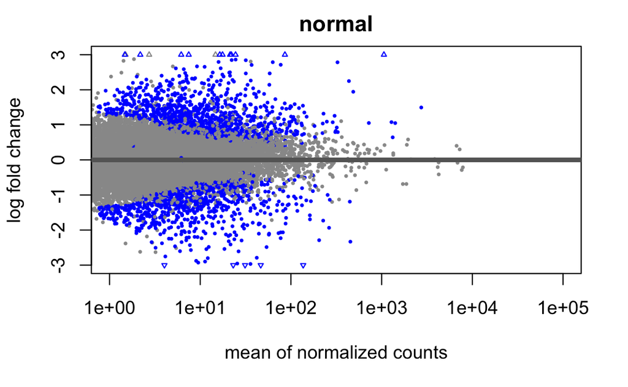

```r
plotMA(resNorm, xlim=xlim, ylim=ylim, main="normal")
```

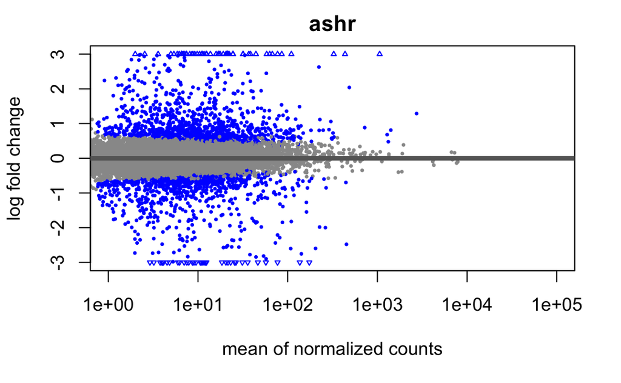

```r
plotMA(resAsh, xlim=xlim, ylim=ylim, main="ashr")
```

```r
#idx <- identify(res$baseMean, res$log2FoldChange)
#rownames(res)[idx]
```

Plot counts

```r
plotCounts(dds, gene=which.min(res$padj), intgroup="condition")
```

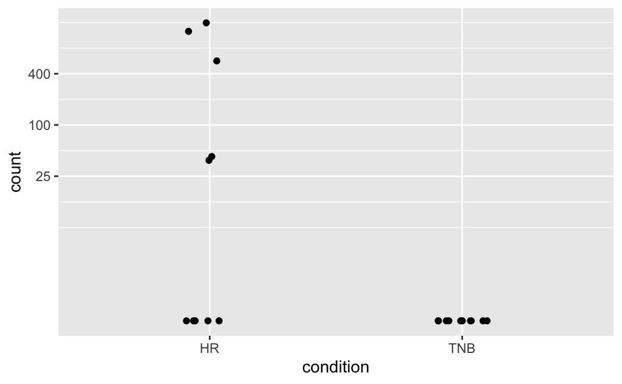

```r
d <- plotCounts(dds, gene=which.min(res$padj), intgroup="condition",
                returnData=TRUE)
library("ggplot2")
ggplot(d, aes(x=condition, y=count)) +
  geom_point(position=position_jitter(w=0.1,h=0)) +
  scale_y_log10(breaks=c(25,100,400))
```

```r
mcols(res)$description
```

```
[1] "mean of normalized counts for all samples"
[2] "log2 fold change (MLE): condition TNB vs HR"
[3] "standard error: condition TNB vs HR"
[4] "Wald statistic: condition TNB vs HR"
[5] "Wald test p-value: condition TNB vs HR"
[6] "BH adjusted p-values"
```

Exporting results to CSV files

```r
resSig <- subset(resOrdered, padj < 0.1)
resSig
```

```
log2 fold change (MLE): condition TNB vs HR
Wald test p-value: condition TNB vs HR
DataFrame with 1959 rows and 6 columns
                    baseMean log2FoldChange     lfcSE      stat
                   <numeric>      <numeric> <numeric> <numeric>
ENSG00000166509.12  174.2410      -26.41001  2.765292  -9.55053
ENSG00000113739.10  136.4698       -4.80333  0.557945  -8.60897
ENSG00000163220.11 1059.5711        7.30287  0.889897   8.20642
ENSG00000171201.12   38.4589       23.57884  2.957084   7.97368
ENSG00000175356.14   46.4821       -6.41324  0.832525  -7.70336
...                      ...            ...       ...       ...
ENSG00000109501.14  15.93160      -0.698132  0.281328  -2.48156
ENSG00000025039.15   4.02516       1.644290  0.662709   2.48116
ENSG00000230882.1    2.65603      -1.993809  0.803751  -2.48063
ENSG00000266714.9    2.51196      -1.484500  0.598456  -2.48055
ENSG00000215375.6    2.20318      -1.393420  0.561765  -2.48043
                        pvalue        padj
                     <numeric>   <numeric>
ENSG00000166509.12 1.29032e-21 1.92465e-17
ENSG00000113739.10 7.37215e-18 5.49815e-14
ENSG00000163220.11 2.27884e-16 1.13304e-12
ENSG00000171201.12 1.54018e-15 5.74334e-12
ENSG00000175356.14 1.32530e-14 3.95362e-11
...                        ...         ...
ENSG00000109501.14   0.0130810   0.0998036
ENSG00000025039.15   0.0130954   0.0998623
ENSG00000230882.1    0.0131150   0.0999150
ENSG00000266714.9    0.0131180   0.0999150
ENSG00000215375.6    0.0131224   0.0999150
```

```r
write.csv(as.data.frame(resOrdered),
          file="TNB_vs_HR_results.csv")
```

Data transformations and visualization:

```r
vsd <- vst(dds, blind=FALSE)
rld <- rlog(dds, blind=FALSE)
head(assay(vsd), 3)
```

```
                   TNB_Sample1 TNB_Sample2 TNB_Sample3 TNB_Sample4
ENSG00000000003.15   4.0256351   4.1351404   5.1545923   3.9257725
ENSG00000000005.6    0.5097997   0.5097997   0.5097997   0.5097997
ENSG00000000419.13   5.9446349   5.6199396   4.4072348   5.2653460
                   TNB_Sample5 TNB_Sample6 TNB_Sample7 TNB_Sample8
ENSG00000000003.15    4.784598   4.7683137   4.8461404   4.5242777
ENSG00000000005.6     2.097901   0.5097997   0.5097997   0.5097997
ENSG00000000419.13    5.355193   5.2630689   4.9100276   4.5898361
                   TNB_Sample9 TNB_Sample10 HR_Sample1 HR_Sample2
ENSG00000000003.15   3.7529210    5.0801876  3.6403883  3.0592161
ENSG00000000005.6    0.5097997    0.5097997  0.5097997  0.5097997
ENSG00000000419.13   5.5217015    5.1926834  4.5428115  5.4863203
                   HR_Sample3 HR_Sample4 HR_Sample5 HR_Sample6
ENSG00000000003.15  4.6723777  2.6860000  3.9923254  2.5952814
ENSG00000000005.6   0.5097997  0.5097997  0.5097997  0.5097997
ENSG00000000419.13  5.3123200  4.9577438  4.6660461  5.8241916
                   HR_Sample7 HR_Sample8 HR_Sample9 HR_Sample10
ENSG00000000003.15   3.945269  5.2410956  2.4616817    4.115107
ENSG00000000005.6    1.672535  0.5097997  0.5097997    1.752255
ENSG00000000419.13   5.352722  5.4802441  5.0028822    4.719865
```

```r
#extract the matrix of normalized values.
```

```r
BiocManager::install("vsn")
```

Effects of transformations on the variance

```r
# this gives log2(n + 1)
ntd <- normTransform(dds)
library("vsn")
meanSdPlot(assay(ntd))
```

```
ℹ The package `hexbin` is required for `stat_binhex()`
✖ Would you like to install it?

1: Yes
2: No
```

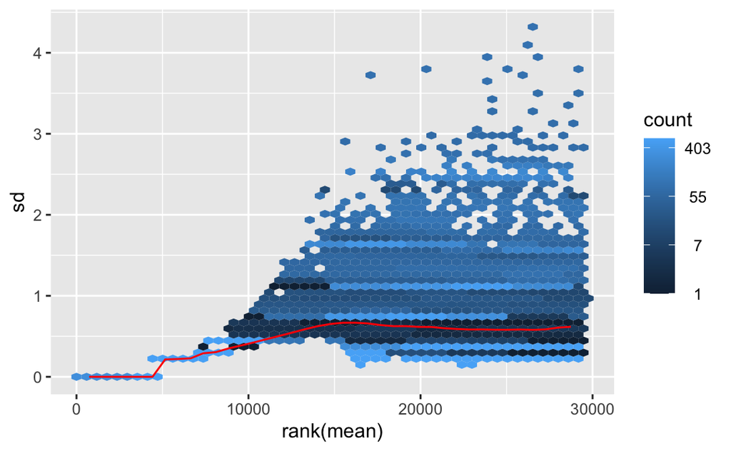

```r
1
```

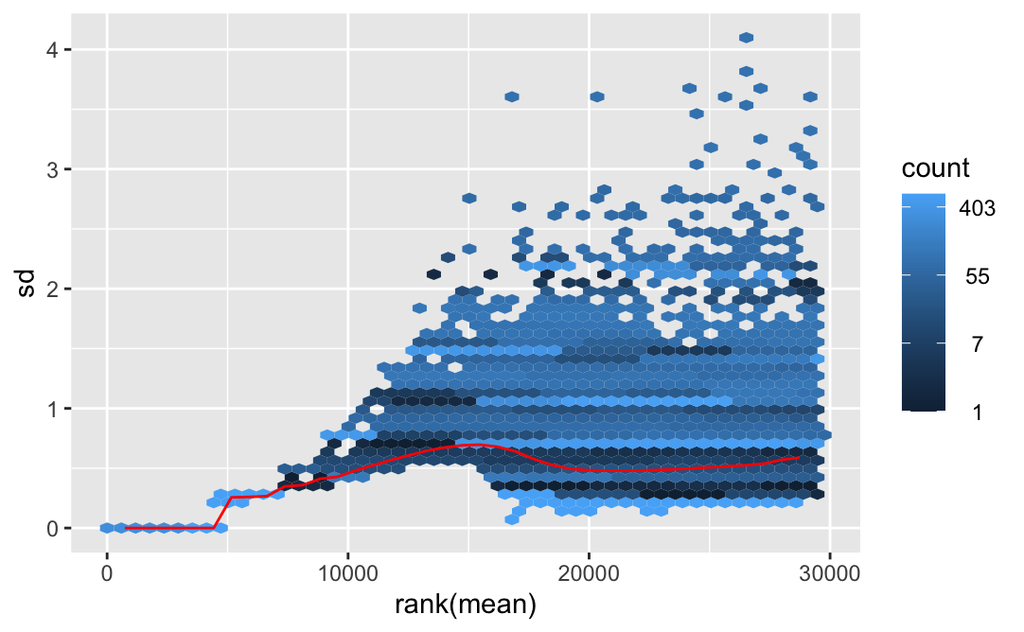

```r
meanSdPlot(assay(vsd))
```

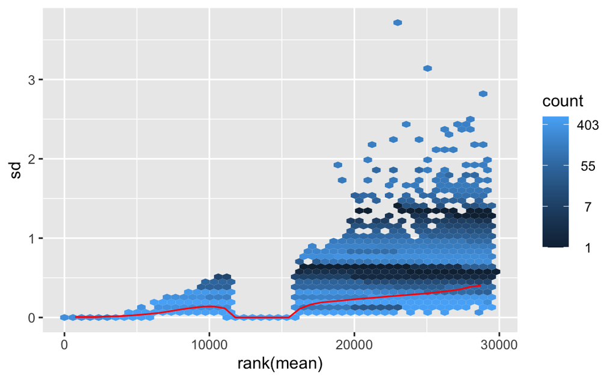

```r
meanSdPlot(assay(rld))
```

Heatmap of the count matrix:

```r
mat.z <- t(apply(mat, 1, scale))
colnames(mat.z) <- rownames(coldata)
##Testing code below
testing <- mat.z
testing <- as.data.frame(testing)
testing$ensembl <- row.names(testing)
library(dplyr)
```

```r
joined <- rename (Joined, 'ensembl' = 'V1')
```

```
Error in rename(Joined, ensembl = "V1") : object 'Joined' not found
```

```r
install.packages("stringr")
```

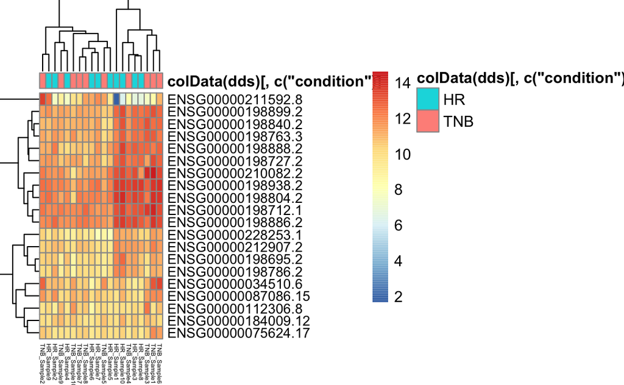

```r
library("pheatmap")
library("stringr")
select <- order(rowMeans(counts(dds,normalized=TRUE)),
                decreasing=TRUE)[1:20]
df <- as.data.frame(colData(dds)[,c("condition")])
colnames(assay(vsd)) <- str_sub(colnames(assay(vsd)), 1, 21)
rownames(df) <- colnames(assay(vsd))
pheatmap(assay(vsd)[select,],cellwidth = 4,cellheight = 8,fontsize_row = 9,fontsize_col =4, annotation_col=df)
```

These are the highest 20 genes expressed in the TNB and HR-positive breast cancer patients. The dark oranage to red represents the highest expression, while the dark blue is the lowerest expression.

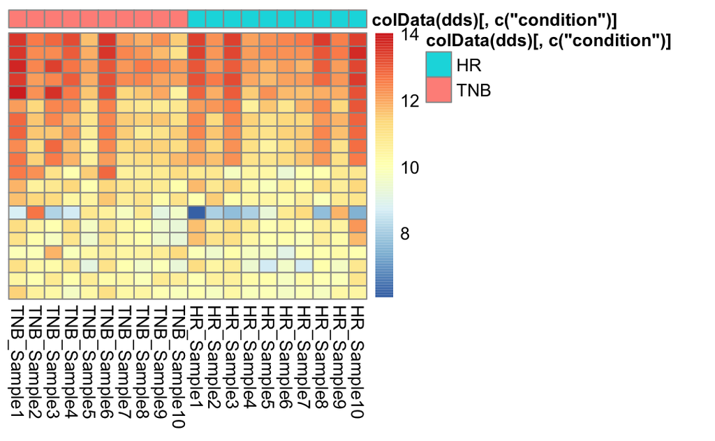

```r
pheatmap(assay(rld)[select,], cluster_rows=FALSE, show_rownames=FALSE,
         cluster_cols=FALSE, annotation_col=df)
```

Heatmap of the sample-to-sample distances

```r
sampleDists <- dist(t(assay(vsd)))
```

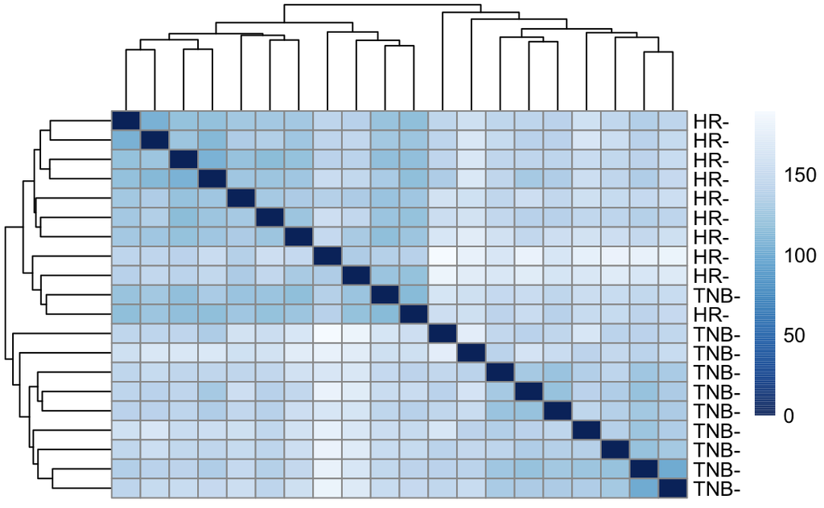

```r
library("RColorBrewer")
sampleDistMatrix <- as.matrix(sampleDists)
rownames(sampleDistMatrix) <- paste(vsd$condition, vsd$type, sep="-")
colnames(sampleDistMatrix) <- NULL
colors <- colorRampPalette( rev(brewer.pal(9, "Blues")) )(255)
pheatmap(sampleDistMatrix,
         clustering_distance_rows=sampleDists,
         clustering_distance_cols=sampleDists,
         col=colors)
```

This heatmap gives an idea of how similar are the samples in terms of gene expression.

Principal component plot of the samples

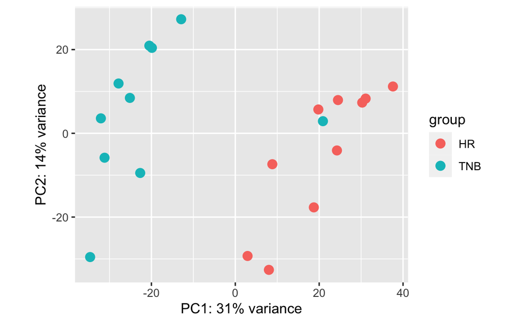

```r
plotPCA(vsd, intgroup=c("condition"))
```

Conclusion: 1. Triple-negative breast cancer in females appeared to show significant differences in gene expression relative to hormone-receptor-positive breast cancers. [heatmap] (https://github.com/alzubeid/TRGN-510-FINAL-PROJECT/blob/main/Image%2012-4-22%20at%209.34%20PM.jpeg)

Known Issues: -Small sample sizes were used to run the test for differential expression, which likely obsecures the true gene expression. -The data obtained from TCGA cases were cross examined with portal.gdc.cancer.gov dataset to obtain the clinical pathology, including estrogn/progestrone/HER2 biomarkers. -The RNA-sequence data showed significantly different PCA analyses between triple negative and estorgen-receptor-positive breast cancer; much greater differences than anticipated.